# R-5

Analyzing the geospatial intersections of job by monthly earnings and SNAP-eligible stores.

Importing LODES data for this analysis.

```r
ca_od <- grab_lodes(
  state = "ca",
  year = 2017,
  lodes_type = "rac",
  job_type = "JT01",
  state_part = "main",
  agg_geo = "bg"
)
saveRDS(ca_od,"ca_od.rds")
```

```r
ca_bg <- block_groups("CA",cb=T,progress_bar=F)

sc_county <-
  counties("CA", cb = T, progress_bar = F, year = 2018) %>%
  filter(NAME == "Santa Clara")

usa_zips <-
  zctas(cb = T, progress_bar = F)

scc_zips <-
  usa_zips %>%
  st_centroid() %>%
  .[sc_county, ] %>%
  st_set_geometry(NULL) %>%
  left_join(usa_zips %>% select(GEOID10)) %>%
  st_as_sf()

scc_bg <-
  ca_bg %>%
  st_centroid() %>%
  .[sc_county, ] %>%
  st_set_geometry(NULL) %>%
  left_join(ca_bg %>% select(GEOID)) %>%
  st_as_sf()

scc_bg %>%
  leaflet() %>%
  addTiles() %>%
  addPolygons()
```

[interactive chart not shown]

```r
scc_od <-
  ca_od %>%
  filter(h_bg %in% scc_bg$GEOID) %>% left_join(
    ca_bg,
    by = c("h_bg"="GEOID")
  ) %>%
  st_as_sf()
```

Visualizing jobs in Santa Clara county (SCC) that pay less than, or equal to, $1,250 per month.

```r
lodes_pal <- colorNumeric(
  palette = "YlGnBu",
  domain = scc_od$CE01
)

leaflet() %>%
  addProviderTiles(providers$CartoDB.Positron) %>%
  addPolygons(
    data = scc_od,
    fillColor = ~lodes_pal(CE01),
    label = ~paste0(h_bg, ": ", CE01),
    color = "black",
    weight = 0.5,
    fillOpacity = 0.25
  ) %>%
  addPolygons(
    data = sc_county,
    fill = F,
    color = "red",
    weight = 2
  ) %>%
  addLegend(
    data = scc_od,
    pal = lodes_pal,
    values = ~CE01,
    title = "Where Santa Clara county jobs<br>are, LODES 2017<br>(<=$1250/month)"
  )
```

[interactive chart not shown]

```r
SFBI_Databse <- read_csv("SFBI Database.csv")

SNAP_access <- SFBI_Databse %>% rename(
  lat= "latitude (from locations) 2",
  long = "longitude (from locations) 2",
  zip = "Zip Code (from address) (from locations) 3"
) %>% filter(SFBI_Databse$taxonomy == "Groceries")

SNAP_coord <- SNAP_access %>% filter(!is.na(lat) & !is.na(long)) %>% filter(lat != "NA, NA" | long != "NA, NA") %>% filter(active == "Open")

SNAP_coord <- st_as_sf(SNAP_coord, coords = c("long","lat"), crs = 4326)

SNAP_coord <- SNAP_coord %>% filter(zip %in% scc_zips$ZCTA5CE10)

leaflet() %>%
  addProviderTiles(providers$CartoDB.Positron) %>%
  addCircleMarkers(
    data = SNAP_coord,
    radius = 1,
    label = ~Name
  )
```

[interactive chart not shown]

Producing a map of SNAP-accessible grocery stores accessible within a 10-minute walking distance in SCC.

```r
walk_10min <- mb_isochrone(
  SNAP_coord,
  profile = "walking",
  time = 10
)

SNAP_walk_10min <-
  SNAP_coord %>%
  st_set_geometry(NULL) %>%
  cbind(walk_10min$geometry) %>%
  st_as_sf()

leaflet() %>%
  addMapboxTiles(
    style_id = "streets-v11",
    username = "mapbox"
  ) %>%
  addPolygons(
    data = SNAP_walk_10min,
    label = ~Name
  )
```

[interactive chart not shown]

```r
scc_bgs <-
  block_groups("CA","085", cb = T, progress_bar = F) %>%
  st_transform(26910) %>%
  mutate(original_area = st_area(.))

scc_bg_isochrone_intersect <-
  scc_bgs %>%
  st_intersection(
    SNAP_walk_10min %>%
      st_union() %>%
      st_transform(26910)
  ) %>%
  mutate(
    leftover_area = st_area(.),
    perc_area = leftover_area / original_area
  )
```

```r
scc_job1 <- scc_od %>% select(h_bg, CE01, BLKGRPCE, AFFGEOID) %>% mutate(job_level = "<= $1,250/month") %>% rename(job_count = CE01)
scc_job2 <- scc_od %>% select(h_bg, CE02, BLKGRPCE, AFFGEOID) %>% mutate(job_level = "$1,250-$3,333/month") %>% rename(job_count = CE02)
scc_job3 <- scc_od %>% select(h_bg, CE03, BLKGRPCE, AFFGEOID) %>% mutate(job_level = ">= $3,333/month") %>% rename(job_count = CE03)

scc_bg_jobs <- rbind(scc_job1, scc_job2, scc_job3)

scc_jobs <- scc_bg_jobs %>% group_by(job_level) %>% summarize(job_count = sum(job_count)) %>%
  mutate(
    perc = job_count/sum(job_count),
    group = "Full Job Count"
  )
```

```r
scc_SNAP_jobs <-
  scc_bg_jobs %>%
  left_join(
    scc_bg_isochrone_intersect %>%
      st_set_geometry(NULL) %>%
      select(AFFGEOID, cbg = GEOID, perc_area),
    by = "AFFGEOID"
  ) %>%
  filter(!is.na(perc_area)) %>%
  mutate(
    job_perc = job_count * perc_area
  ) %>%
  group_by(job_level) %>%
  summarize(job_count = sum(job_count)) %>%
  mutate(
    perc = job_count/sum(job_count),
    group = "Jobs within 10 min. walk of SNAP stores"
  )
sum(scc_SNAP_jobs$job_count)/
  sum(scc_jobs$job_count)
```

```
## [1] 0.9214925
```

92% of jobs in SCC exist within a 10-minute walking distance of SNAP-eligible retailers.

The next portion of this analysis will investigate whether the prevalence of jobs in these SNAP-isochrones varies based on monthly earnings.

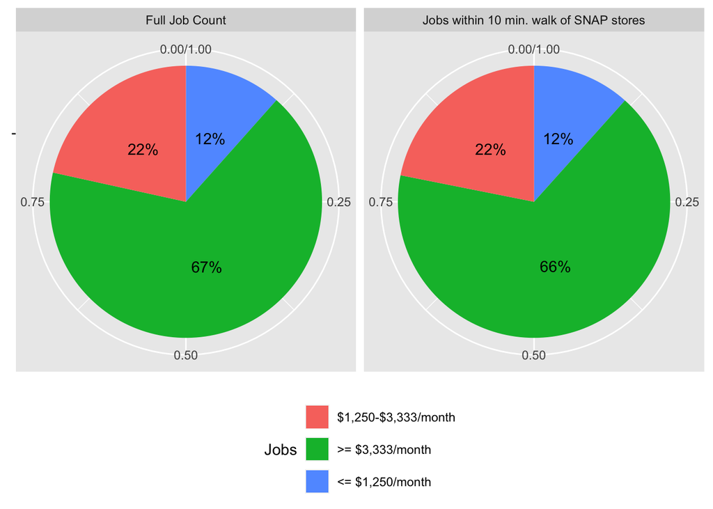

```r
rbind(scc_jobs,scc_SNAP_jobs) %>%
  ggplot(
    aes(
      x = "",
      y = perc,
      fill = reorder(job_level,desc(job_level))
    )
  ) +
  geom_bar(
    stat = "identity",
    position = position_fill()
  ) +
  geom_text(
    aes(label = paste0(round(perc*100),"%")),
    position = position_fill(vjust = 0.5)
  ) +
  coord_polar(theta = "y") +
  facet_wrap(~ group)  +
  theme(
    axis.title.x = element_blank(),
    axis.title.y = element_blank(),
    legend.position = 'bottom'
  ) +
  guides(
    fill = guide_legend(nrow=3, byrow=TRUE)
  ) +
  labs(
    fill = "Jobs"
  )
```

From these two graphs, it appears that the composition of jobs by earnings is nearly the same across the county as it is within 10 minutes walking of SNAP stores, with a slight decrease in jobs earning greater than, or equal to, $3,333 per month. From this analysis, it is difficult to draw conclusions regarding accessibility to SNAP-eligible retailers based on jobs and their level of earnings, which I had imagined as a sort of supplement to household income information. Below, I conduct an equity analysis on the basis of household income form ACS data.

```r
scc_bg_income <-
  getCensus(
    name = "acs/acs5",
    vintage = 2018,
    region = "block group:*",
    regionin = "state:06+county:085",
    vars = "group(B19001)"
  ) %>%
  mutate(cbg = paste0(state,county,tract,block_group)) %>%
  select(!c(GEO_ID,state,county,tract,block_group,NAME) & !ends_with(c("EA","MA","M"))) %>%
  pivot_longer(
    ends_with("E"),
    names_to = "variable",
    values_to = "estimate"
  ) %>%
  left_join(
    acs_vars_2018_5yr %>%
      select(name, label),
    by = c("variable" = "name")
  ) %>%
  select(-variable) %>%
  separate(
    label,
    into = c(NA,NA,"income"),
    sep = "!!"
  ) %>%
  filter(!is.na(income)) %>%
  mutate(
    income = case_when(
      income %in% c("Less than $10,000","$10,000 to $14,999","$15,000 to $19,999","$20,000 to $24,999") ~ "Less than $25,000",
      income %in% c("$25,000 to $29,999","$30,000 to $34,999","$35,000 to $39,999","$40,000 to $44,999","$45,000 to $49,999") ~ "$25,000 to $49,999",
      income %in% c("$50,000 to $59,999","$60,000 to $74,999") ~ "$50,000 to $74,999",
      TRUE ~ income
    )
  )

scc_income <-
  scc_bg_income %>%
  mutate(income = factor(income, levels = unique(scc_bg_income$income))) %>%
  group_by(income) %>%
  summarize(estimate = sum(estimate)) %>%
  mutate(
    perc = estimate/sum(estimate),
    group = "Full Population"
  )
scc_SNAP_income <-
  scc_bg_income %>%
  mutate(income = factor(income, levels = unique(scc_bg_income$income))) %>%
  left_join(
    scc_bg_isochrone_intersect %>%
      select(cbg = GEOID, perc_area) %>%
      st_set_geometry(NULL)
  ) %>%
  filter(!is.na(perc_area)) %>%
  mutate(
    estimate = estimate * perc_area
  ) %>%
  group_by(income) %>%
  summarize(estimate = sum(estimate)) %>%
  mutate(
    perc = estimate/sum(estimate),
    group = "Population within 10 min. walk of SNAP stores"
  )
sum(scc_SNAP_income$estimate)/
  sum(scc_income$estimate)
```

[output not shown]

An estimated 56% of the population of SCC is within a 10-minute walking distance of SNAP-eligible retailers.

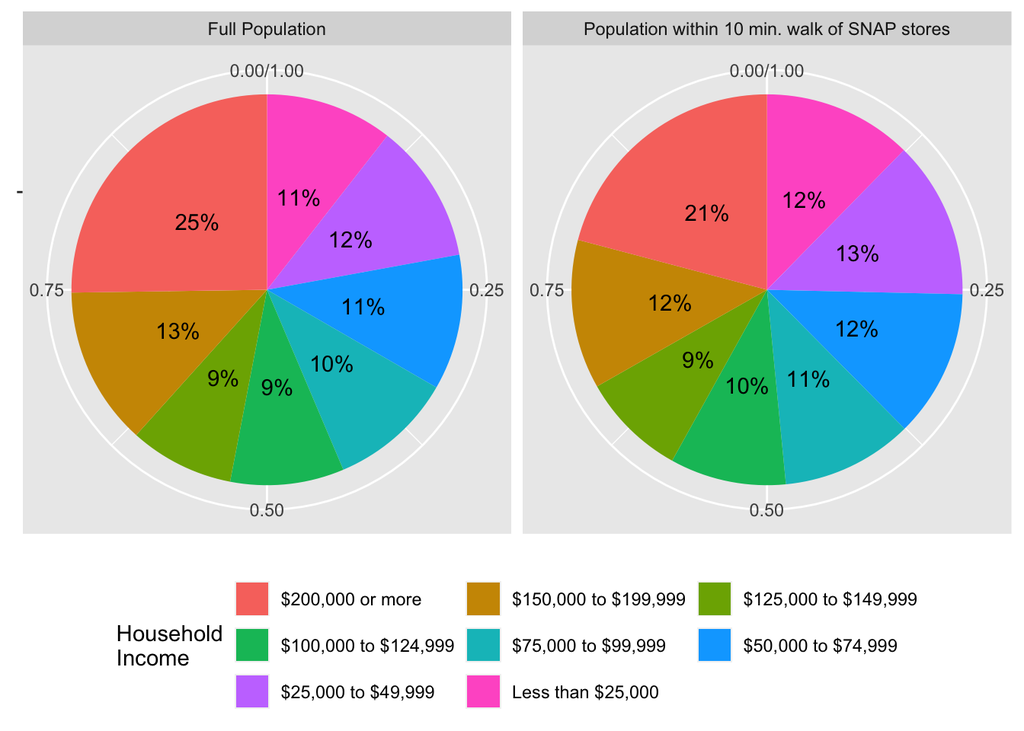

```r
rbind(scc_income,scc_SNAP_income) %>%
  ggplot(
    aes(
      x = "",
      y = perc,
      fill = reorder(income,desc(income))
    )
  ) +
  geom_bar(
    stat = "identity",
    position = position_fill()
  ) +
  geom_text(
    aes(label = paste0(round(perc*100),"%")),
    position = position_fill(vjust = 0.5)
  ) +
  coord_polar(theta = "y") +
  facet_wrap(~ group)  +
  theme(
    axis.title.x = element_blank(),
    axis.title.y = element_blank(),
    legend.position = 'bottom'
  ) +
  guides(
    fill = guide_legend(nrow=3, byrow=TRUE)
  ) +
  labs(
    fill = "Household\nIncome"
  )
```

These pie charts suggests that SNAP-eligible retailers are serving lower-income residents (<= $99,900 HI) at a slightly higher proportion than higher-income residents (> $99,900 HI). While this is a positive result, it is unclear how many low-income residents are not accounted for this in analysis, and therefore, live outside an easily-accessible distance from affordable food options.